# SYNTHESIS EXERCISE

Marta Españó López

6/6/2020

Marta Espano Lopez 104532

Link to my github repository: https://github.com/Martaesplo/omics_techniques.git

GEO accession number: GSE52553

Libraries needed:

```r
library(methods)
library(Biobase)
library(BiocManager)
library(BiocVersion)
library(GEOquery)
library(limma)
library(pd.mogene.1.0.st.v1)
library(mogene10sttranscriptcluster.db)
library(oligo)
library(limma)
library(genefilter)
library(multtest)
library(annotate)
library(gplots)
library(scatterplot3d)
```

DATA DESCRIPTION

- Study:  
  Ethanol treatment of lymphoblastoid cell lines from alcoholics and non-alcoholics causes many subtle changes in gene expression.
- Description of the study: To understand the effect of controlled exposure to ethanol on gene expression, lymphoblastoid cell lines (LCLs) from 21 alcoholics and 21 controls were studied after a treatment of 24 hours. Gene expression was meassured using microarrays which together with a paired design allowed to detect very small changes between the cell lines due to ethanol treatment.

First we download the GEO dataset GSE52553 and since is has a sample size of 84, we choose a subset of it containing 12 samples. Those are balanced according to the existent groups.

```r
gse <- getGEO("GSE52553")
eset<-gse[[1]]

rdeset<-(eset[1:11,c(1,3,2,4,43,44,66,70,30,29,69,65)])

dim(exprs(rdeset))
dim(exprs(eset))
head(rdeset)
exprs(rdeset)
head(exprs(rdeset))
targets<-pData(rdeset)
targets
```

[output not shown]

```r
pcs<-prcomp(exprs(rdeset))

print(paste0('Mean of st.deviation = ',mean(pcs$sdev)))
```

```
## [1] "Mean of st.deviation = 519.548455830303"
```

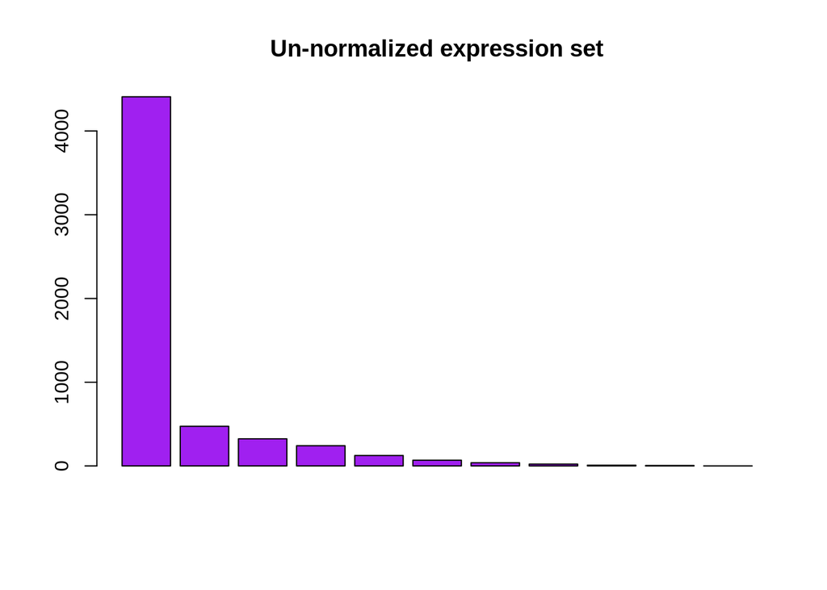

```r
barplot(pcs$sdev, col='purple', main='Un-normalized expression set')
```

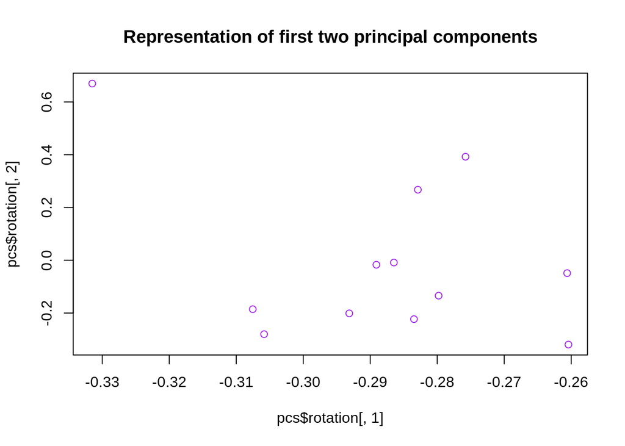

```r
plot(pcs$rotation[,1], pcs$rotation[,2], main="Representation of first two principal components", col='purple')
```

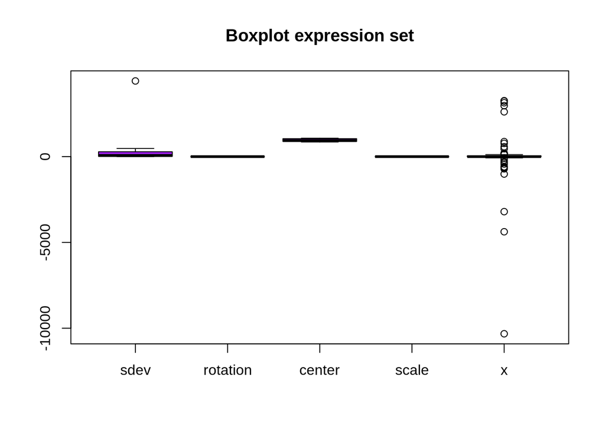

```r
boxplot(pcs, col='purple', main='Boxplot expression set')
```

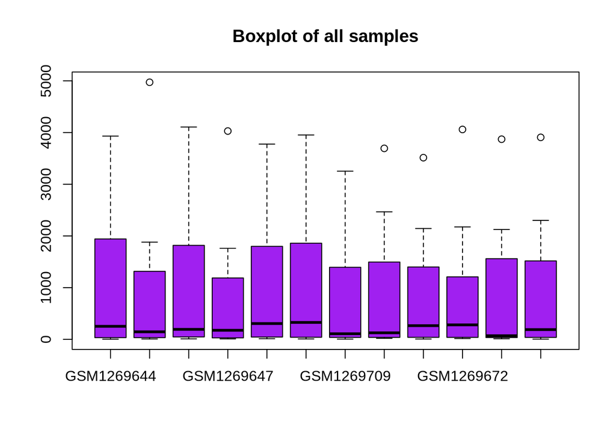

```r
boxplot(exprs(rdeset), col='purple', main='Boxplot of all samples')
```

[figure not shown]

```r
n<- matrix(rnorm(targets))

hist(n, col='purple', main='Normalized expression set')
```

- Information of the experimental design:

Response variable: Gene expression  
Depends on: ethanol Treatment and being alcoholic or not  
Factors and groups: Treatment/no treatment and alcoholic/non-alcoholic(control)  
Sample size: 12 (84 originally), 3 samples belonging to each group  
Experimental units per combination of factors: 3  
Type of experimental design: Block design  
Replicate type: Biological

In the study the variable sex (female or male) is also specified, but we will ignore it.

g1 = no tretment, alcoholic  
g2 = treatment, alcoholic  
g3 = no treatment, non-alcoholic  
g4 = treatment, non-alcoholic

g1 vs g2  
g1 vs g4  
g3 vs g2  
g3 vs g4

- Build a design and contrast matrix:

```r
treat<-targets$source_name_ch1
lev<-factor(treat,levels = unique(treat))
design <- model.matrix(~0+lev)
colnames(design)<-c('g1','g2','g3','g4')
print(design)
```

```
##    g1 g2 g3 g4
## 1   1  0  0  0
## 2   1  0  0  0
## 3   0  1  0  0
## 4   0  1  0  0
## 5   0  0  1  0
## 6   0  0  0  1
## 7   0  1  0  0
## 8   0  0  0  1
## 9   0  0  0  1
## 10  0  0  1  0
## 11  0  0  1  0
## 12  1  0  0  0
## attr(,"assign")
## [1] 1 1 1 1
## attr(,"contrasts")
## attr(,"contrasts")$lev
## [1] "contr.treatment"
```

```r
cont.matrix1<-makeContrasts(g1-g2,g1-g4,g3-g2,g3-g4,levels = design)
fit1<-lmFit(rdeset,design)
fit.main1 <-contrasts.fit(fit1,cont.matrix1)
fit.main1<-eBayes(fit.main1)
cont.matrix1
```

```
##       Contrasts
## Levels g1 - g2 g1 - g4 g3 - g2 g3 - g4
##     g1       1       1       0       0
##     g2      -1       0      -1       0
##     g3       0       0       1       1
##     g4       0      -1       0      -1
```

- Build the topTable and a volcano plot:

```r
topTab <-  topTable (fit.main1, number=nrow(fit.main1), adjust="fdr",lfc=abs(3))
topTab
```

```
##                  ID GB_ACC SPOT_ID Species.Scientific.Name Annotation.Date
## 1316_at     1316_at X55005      NA            Homo sapiens     Oct 6, 2014
## 1431_at     1431_at J02843      NA            Homo sapiens     Oct 6, 2014
## 1053_at     1053_at M87338      NA            Homo sapiens     Oct 6, 2014
## 1255_g_at 1255_g_at L36861      NA            Homo sapiens     Oct 6, 2014
## 1438_at     1438_at X75208      NA            Homo sapiens     Oct 6, 2014
## 1294_at     1294_at L13852      NA            Homo sapiens     Oct 6, 2014
## 1320_at     1320_at X79510      NA            Homo sapiens     Oct 6, 2014
## 117_at       117_at X51757      NA            Homo sapiens     Oct 6, 2014
## 1405_i_at 1405_i_at M21121      NA            Homo sapiens     Oct 6, 2014
## 1007_s_at 1007_s_at U48705      NA            Homo sapiens     Oct 6, 2014
## 121_at       121_at X69699      NA            Homo sapiens     Oct 6, 2014
##               Sequence.Type                 Sequence.Source
## 1316_at   Exemplar sequence Affymetrix Proprietary Database
## 1431_at   Exemplar sequence Affymetrix Proprietary Database
## 1053_at   Exemplar sequence                         GenBank
## 1255_g_at Exemplar sequence Affymetrix Proprietary Database
## 1438_at   Exemplar sequence Affymetrix Proprietary Database
## 1294_at   Exemplar sequence                         GenBank
## 1320_at   Exemplar sequence Affymetrix Proprietary Database
## 117_at    Exemplar sequence Affymetrix Proprietary Database
## 1405_i_at Exemplar sequence                         GenBank
## 1007_s_at Exemplar sequence Affymetrix Proprietary Database
## 121_at    Exemplar sequence                         GenBank
##                                                                                                                                Target.Description
## 1316_at                   X55005 /FEATURE=mRNA /DEFINITION=HSCERBAR Homo sapiens mRNA for thyroid hormone receptor alpha 1 THRA1, (c-erbA-1 gene)
## 1431_at                                J02843 /FEATURE=cds /DEFINITION=HUMCYPIIE Human cytochrome P450IIE1 (ethanol-inducible) gene, complete cds
## 1053_at                                  M87338 /FEATURE= /DEFINITION=HUMA1SBU Human replication factor C, 40-kDa subunit (A1) mRNA, complete cds
## 1255_g_at L36861 /FEATURE=expanded_cds /DEFINITION=HUMGCAPB Homo sapiens guanylate cyclase activating protein (GCAP) gene exons 1-4, complete cds
## 1438_at                                           X75208 /FEATURE=cds /DEFINITION=HSPTKR H.sapiens HEK2 mRNA for protein tyrosine kinase receptor
## 1294_at                      L13852 /FEATURE= /DEFINITION=HUME1URP Homo sapiens ubiquitin-activating enzyme E1 related protein mRNA, complete cds
## 1320_at                                                X79510 /FEATURE=cds /DEFINITION=HSPTPD1 H.sapiens mRNA for protein-tyrosine-phosphatase D1
## 117_at                                                               X51757 /FEATURE=cds /DEFINITION=HSP70B Human heat-shock protein HSP70B' gene
## 1405_i_at                                          M21121 /FEATURE= /DEFINITION=HUMTCSM Human T cell-specific protein (RANTES) mRNA, complete cds
## 1007_s_at                                         U48705 /FEATURE=mRNA /DEFINITION=HSU48705 Human receptor tyrosine kinase DDR gene, complete cds
## 121_at                                                                                   X69699 /FEATURE= /DEFINITION=HSPAX8A H.sapiens Pax8 mRNA
##           Representative.Public.ID
## 1316_at                     X55005
## 1431_at                     J02843
## 1053_at                     M87338
```

[output cut: 89 more lines]

```
## 1405_i_at -56.910000  -99.7533333 -269.11667 -311.960000 1876.36750 0.3771694
## 1007_s_at  85.919333   88.7846667  184.91133  187.776667 1249.84333 0.1954486
## 121_at     74.872333   41.7376667   46.12200   12.987333  822.13825 0.0937003
##              P.Value adj.P.Val
## 1316_at   0.09375693 0.9434098
## 1431_at   0.27591217 0.9434098
## 1053_at   0.37445373 0.9434098
## 1255_g_at 0.46734123 0.9434098
## 1438_at   0.58558329 0.9434098
## 1294_at   0.62697899 0.9434098
## 1320_at   0.71774500 0.9434098
## 117_at    0.73016592 0.9434098
## 1405_i_at 0.77188078 0.9434098
## 1007_s_at 0.89680682 0.9615694
## 121_at    0.96156936 0.9615694
```

[figure not shown]

```r
volcanoplot(fit.main1, highlight=10, names=fit.main1$ID,
            main=paste("Differentially expressed genes",colnames(cont.matrix1), sep="\n"))
abline(v=c(-1,1))
```

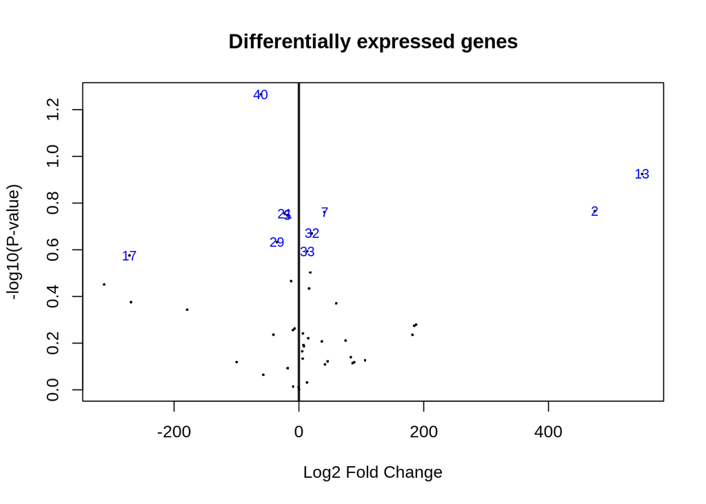

```r
volcanoplot(fit.main1, highlight=10, names=fit.main1$ID,
            main="Differentially expressed genes",colnames(cont.matrix1))
abline(v=c(-1,1))
```